# Hotel Booking Cancellations Analysis

## Introduction

This notebook analyzes a hotel booking dataset to understand patterns and factors influencing cancellations. The dataset includes various features related to bookings, customer demographics, and stay details. The objective is to extract insights and build predictive models to minimize cancellations and optimize hotel operations.

## Dataset Description

The dataset contains the following columns:

- hotel: The type of hotel (city hotel or resort hotel).
- is_canceled: Indicates if the booking was canceled (1) or not (0).
- lead_time: The number of days between the booking date and the arrival date.
- arrival_date_year: The year of arrival date.
- arrival_date_month: The month of arrival date.
- arrival_date_week_number: The week number of the arrival date.
- arrival_date_day_of_month: The day of the month of the arrival date.
- stays_in_weekend_nights: Number of weekend nights (Saturday and Sunday) the guest stayed or booked to stay at the hotel.
- stays_in_week_nights: Number of week nights (Monday to Friday) the guest stayed or booked to stay at the hotel.
- adults: Number of adults.
- children: Number of children.
- babies: Number of babies.
- meal: Type of meal booked (e.g., BB - Bed & Breakfast, HB - Half Board, FB - Full Board).
- country: Country of origin of the guest.
- market_segment: Market segment designation (e.g., Direct, Corporate, Online TA).
- distribution_channel: Booking distribution channel (e.g., Direct, TA/TO).
- is_repeated_guest: Indicates if the guest is a repeated guest (1) or not (0).
- previous_cancellations: Number of previous bookings that were canceled by the customer prior to the current booking.
- previous_bookings_not_canceled: Number of previous bookings not canceled by the customer prior to the current booking.
- reserved_room_type: Code of room type reserved.

assigned_room_type: Code of room type assigned.

- booking_changes: Number of changes/amendments made to the booking.
- deposit_type: Type of deposit made (e.g., No Deposit, Non Refund, Refundable).
- agent: ID of the travel agent who made the booking.
- company: ID of the company/entity that made the booking or responsible for the booking.
- days_in_waiting_list: Number of days the booking was in the waiting list before it was confirmed to the customer.
- customer_type: Type of booking (e.g., Contract, Group, Transient).
- adr: Average Daily Rate, as defined by dividing the sum of all lodging transactions by the total number of staying nights.
- required_car_parking_spaces: Number of car parking spaces required by the customer.
- total_of_special_requests: Total number of special requests made by the customer (e.g., high floor, crib, etc.).
- reservation_status: Reservation last status (e.g., Canceled, Check-Out, No-Show).
- reservation_status_date: Date at which the last status was set.

#### To extract data from an API, you'll typically follow these steps:

Understand the API Documentation: Review the API documentation to understand the endpoints, request methods, required parameters, and authentication mechanisms.

Set Up Your Environment: Ensure you have the necessary libraries installed. For Python, common libraries include requests for making HTTP requests and json for handling JSON data.

Make the API Request: Use the requests library to make a GET or POST request to the API endpoint.

Handle the Response: Check the response status code to ensure the request was successful. If successful, parse the JSON data from the response.

Process the Data: Depending on your needs, you can process, analyze, or store the extracted data.

```python
# Import necessary libraries
import requests
import pandas as pd
import json
```

```python
# Define the API endpoint and any necessary headers (e.g., for authentication)
api_url = "https://api.hotel.com/v1/bookings"
headers = {
    "Authorization": "0524sdfw_45723dfrty00ty0w"
}

# Make the API request
response = requests.get(api_url, headers=headers)

# Check if the request was successful
if response.status_code == 200:
    # Parse the response JSON into a dictionary
    data = response.json()

    # If the data is nested, you may need to adjust this step to flatten it appropriately
    bookings = data['bookings']

    # Convert the dictionary to a Pandas DataFrame
    df = pd.DataFrame(bookings)

    # Display the DataFrame
    print(df.head())
else:
    print(f"Failed to retrieve data: {response.status_code}")

# Save the DataFrame to a CSV file
df.to_csv('hotel_bookings.csv', index=False)
```

```python
import pandas as pd
import numpy as np
import seaborn as sns
import matplotlib.pyplot as plt
%matplotlib inline
```

```python
hotel_df = pd.read_csv(r'hotel_bookings.csv')
```

```python
hotel_df.shape
```

```
(119390, 32)
```

```python
hotel_df.dtypes
```

```
hotel                              object
is_canceled                         int64
lead_time                           int64
arrival_date_year                   int64
arrival_date_month                 object
arrival_date_week_number            int64
arrival_date_day_of_month           int64
stays_in_weekend_nights             int64
stays_in_week_nights                int64
adults                              int64
children                          float64
babies                              int64
meal                               object
country                            object
market_segment                     object
distribution_channel               object
is_repeated_guest                   int64
previous_cancellations              int64
previous_bookings_not_canceled      int64
reserved_room_type                 object
assigned_room_type                 object
booking_changes                     int64
deposit_type                       object
agent                             float64
company                           float64
days_in_waiting_list                int64
customer_type                      object
adr                               float64
required_car_parking_spaces         int64
total_of_special_requests           int64
reservation_status                 object
reservation_status_date            object
dtype: object
```

```python
hotel_df.info()
```

```
<class 'pandas.core.frame.DataFrame'>
RangeIndex: 119390 entries, 0 to 119389
Data columns (total 32 columns):
 #   Column                          Non-Null Count   Dtype
---  ------                          --------------   -----
 0   hotel                           119390 non-null  object
 1   is_canceled                     119390 non-null  int64
 2   lead_time                       119390 non-null  int64
 3   arrival_date_year               119390 non-null  int64
 4   arrival_date_month              119390 non-null  object
 5   arrival_date_week_number        119390 non-null  int64
 6   arrival_date_day_of_month       119390 non-null  int64
 7   stays_in_weekend_nights         119390 non-null  int64
 8   stays_in_week_nights            119390 non-null  int64
 9   adults                          119390 non-null  int64
```

[output cut: 24 more lines]

#### Types of Data

1. Categorical data refers to a data type that can be stored

into groups/categories/labels.

- Examples of categorical variables are :

age group, educational level,blood type etc.

2. Numerical data refers to the data that is in the form of numbers,
- Examples of numerical data are height, weight, age etc.

#### Numerical data has two categories: discrete data and continuous data

- Discrete data : It basically takes countable numbers like 1, 2, 3, 4, 5, and so on. In case of infinity, these numbers will keep going on. Age of a fly : 8 , 9 day etc..
- Continuous data : which is continuous in nature amount of sugar , 11.2 kg, temp of a cit, your bank balance !

For example, salary levels and performance classifications are discrete variables, whereas height and weight are continuous variables.

- Categorical data has : Object & bool data-types
- Numerical data have : Integer & Float data-type

#### Variations of int are : ('int64','int32','int16') in numpy library.

- Int16 is a 16 bit signed integer , it means it can store both positive & negative values

-- int16 has has a range of (2^15 − 1) to -2^15 -- int16 has a length of 16 bits (2 bytes).. ie Int16 uses 16 bits

- Int32 is a 32 bit signed integer , it means it stores both positive & negative values

-- int32 has has a range of (2³¹ − 1) to -2^31 -- int32 has a length of 32 bits (4 bytes),, ie Int32 uses 32 bits

- Int64 is a 64 bit signed integer , it means it can store both positive & negative values

-- int64 has has a range of (2^63 − 1) to -2^63 -- int64 has a length of 64 bits (8 bytes) , ie Int64 uses 64 bits.

The only difference is that int64 has max range of storing numbers , then comes int32 , then 16 , then int8

That means that Int64’s take up twice as much memory-and doing operations on them may be a lot slower in some machine architectures.

However, Int64’s can represent numbers much more accurately than 32 bit floats.They also allow much larger numbers to be stored..

## Data Cleaning

```python
hotel_df.head(6)
```

|  | hotel | is_canceled | lead_time | arrival_date_year | arrival_date_month | arrival_date_week_number | arrival_date_day_of_month | stays_in_weekend_nights | stays_in_week_nights | adults | ... | deposit_type | agent | company | days_in_waiting_list | customer_type | adr | required_car_parking_spaces | total_of_special_requests | reservation_status | reservation_status_date |
| --- | --- | --- | --- | --- | --- | --- | --- | --- | --- | --- | --- | --- | --- | --- | --- | --- | --- | --- | --- | --- | --- |
| 0 | Resort Hotel | 0 | 342 | 2015 | July | 27 | 1 | 0 | 0 | 2 | ... | No Deposit | NaN | NaN | 0 | Transient | 0.0 | 0 | 0 | Check-Out | 7/1/2015 |
| 1 | Resort Hotel | 0 | 737 | 2015 | July | 27 | 1 | 0 | 0 | 2 | ... | No Deposit | NaN | NaN | 0 | Transient | 0.0 | 0 | 0 | Check-Out | 7/1/2015 |
| 2 | Resort Hotel | 0 | 7 | 2015 | July | 27 | 1 | 0 | 1 | 1 | ... | No Deposit | NaN | NaN | 0 | Transient | 75.0 | 0 | 0 | Check-Out | 7/2/2015 |
| 3 | Resort Hotel | 0 | 13 | 2015 | July | 27 | 1 | 0 | 1 | 1 | ... | No Deposit | 304.0 | NaN | 0 | Transient | 75.0 | 0 | 0 | Check-Out | 7/2/2015 |
| 4 | Resort Hotel | 0 | 14 | 2015 | July | 27 | 1 | 0 | 2 | 2 | ... | No Deposit | 240.0 | NaN | 0 | Transient | 98.0 | 0 | 1 | Check-Out | 7/3/2015 |
| 5 | Resort Hotel | 0 | 14 | 2015 | July | 27 | 1 | 0 | 2 | 2 | ... | No Deposit | 240.0 | NaN | 0 | Transient | 98.0 | 0 | 1 | Check-Out | 7/3/2015 |

6 rows × 32 columns

```python
hotel_df.columns
```

```
Index(['hotel', 'is_canceled', 'lead_time', 'arrival_date_year',
       'arrival_date_month', 'arrival_date_week_number',
       'arrival_date_day_of_month', 'stays_in_weekend_nights',
       'stays_in_week_nights', 'adults', 'children', 'babies', 'meal',
       'country', 'market_segment', 'distribution_channel',
       'is_repeated_guest', 'previous_cancellations',
       'previous_bookings_not_canceled', 'reserved_room_type',
       'assigned_room_type', 'booking_changes', 'deposit_type', 'agent',
       'company', 'days_in_waiting_list', 'customer_type', 'adr',
       'required_car_parking_spaces', 'total_of_special_requests',
       'reservation_status', 'reservation_status_date'],
      dtype='object')
```

```python
# Adults,babies & children cant be zero at a same time because booking couldn't be possible if these 3 attributes are 0 .
filter1 = (hotel_df['children']==0) & (hotel_df['adults']==0) & (hotel_df['babies']==0)
```

```python
filter1
```

```
0         False
1         False
2         False
3         False
4         False
          ...
119385    False
119386    False
119387    False
119388    False
119389    False
Length: 119390, dtype: bool
```

```python
hotel_df[filter1]
```

|  | hotel | is_canceled | lead_time | arrival_date_year | arrival_date_month | arrival_date_week_number | arrival_date_day_of_month | stays_in_weekend_nights | stays_in_week_nights | adults | ... | deposit_type | agent | company | days_in_waiting_list | customer_type | adr | required_car_parking_spaces | total_of_special_requests | reservation_status | reservation_status_date |
| --- | --- | --- | --- | --- | --- | --- | --- | --- | --- | --- | --- | --- | --- | --- | --- | --- | --- | --- | --- | --- | --- |
| 2224 | Resort Hotel | 0 | 1 | 2015 | October | 41 | 6 | 0 | 3 | 0 | ... | No Deposit | NaN | 174.0 | 0 | Transient-Party | 0.00 | 0 | 0 | Check-Out | 10/6/2015 |
| 2409 | Resort Hotel | 0 | 0 | 2015 | October | 42 | 12 | 0 | 0 | 0 | ... | No Deposit | NaN | 174.0 | 0 | Transient | 0.00 | 0 | 0 | Check-Out | 10/12/2015 |
| 3181 | Resort Hotel | 0 | 36 | 2015 | November | 47 | 20 | 1 | 2 | 0 | ... | No Deposit | 38.0 | NaN | 0 | Transient-Party | 0.00 | 0 | 0 | Check-Out | 11/23/2015 |
| 3684 | Resort Hotel | 0 | 165 | 2015 | December | 53 | 30 | 1 | 4 | 0 | ... | No Deposit | 308.0 | NaN | 122 | Transient-Party | 0.00 | 0 | 0 | Check-Out | 1/4/2016 |
| 3708 | Resort Hotel | 0 | 165 | 2015 | December | 53 | 30 | 2 | 4 | 0 | ... | No Deposit | 308.0 | NaN | 122 | Transient-Party | 0.00 | 0 | 0 | Check-Out | 1/5/2016 |
| ... | ... | ... | ... | ... | ... | ... | ... | ... | ... | ... | ... | ... | ... | ... | ... | ... | ... | ... | ... | ... | ... |
| 115029 | City Hotel | 0 | 107 | 2017 | June | 26 | 27 | 0 | 3 | 0 | ... | No Deposit | 7.0 | NaN | 0 | Transient | 100.80 | 0 | 0 | Check-Out | 6/30/2017 |
| 115091 | City Hotel | 0 | 1 | 2017 | June | 26 | 30 | 0 | 1 | 0 | ... | No Deposit | NaN | NaN | 0 | Transient | 0.00 | 1 | 1 | Check-Out | 7/1/2017 |
| 116251 | City Hotel | 0 | 44 | 2017 | July | 28 | 15 | 1 | 1 | 0 | ... | No Deposit | 425.0 | NaN | 0 | Transient | 73.80 | 0 | 0 | Check-Out | 7/17/2017 |
| 116534 | City Hotel | 0 | 2 | 2017 | July | 28 | 15 | 2 | 5 | 0 | ... | No Deposit | 9.0 | NaN | 0 | Transient-Party | 22.86 | 0 | 1 | Check-Out | 7/22/2017 |
| 117087 | City Hotel | 0 | 170 | 2017 | July | 30 | 27 | 0 | 2 | 0 | ... | No Deposit | 52.0 | NaN | 0 | Transient | 0.00 | 0 | 0 | Check-Out | 7/29/2017 |

180 rows × 32 columns

```python
hotel_df.shape
```

```
(119390, 32)
```

```python
hotel_df[filter1].shape
```

```
(180, 32)
```

```python
hotel_df2 = hotel_df[~filter1]
```

```python
hotel_df2.shape
```

```
(119210, 32)
```

```python
len(hotel_df2[(hotel_df2['children'] == 1) & (hotel_df2['adults'] == 0) & (hotel_df2['babies'] == 0)])
```

```
4
```

### Removing Duplicated data

```python
hotel_df2.duplicated()
```

```
0         False
1         False
2         False
3         False
4         False
          ...
119385    False
119386    False
119387    False
119388    False
119389    False
Length: 119210, dtype: bool
```

```python
hotel_df2.duplicated().sum()
```

```
31980
```

```python
hotel_data = hotel_df2.drop_duplicates()
```

```python
hotel_data.shape
```

```
(87230, 32)
```

```python
hotel_data.head(7)
```

|  | hotel | is_canceled | lead_time | arrival_date_year | arrival_date_month | arrival_date_week_number | arrival_date_day_of_month | stays_in_weekend_nights | stays_in_week_nights | adults | ... | deposit_type | agent | company | days_in_waiting_list | customer_type | adr | required_car_parking_spaces | total_of_special_requests | reservation_status | reservation_status_date |
| --- | --- | --- | --- | --- | --- | --- | --- | --- | --- | --- | --- | --- | --- | --- | --- | --- | --- | --- | --- | --- | --- |
| 0 | Resort Hotel | 0 | 342 | 2015 | July | 27 | 1 | 0 | 0 | 2 | ... | No Deposit | NaN | NaN | 0 | Transient | 0.0 | 0 | 0 | Check-Out | 7/1/2015 |
| 1 | Resort Hotel | 0 | 737 | 2015 | July | 27 | 1 | 0 | 0 | 2 | ... | No Deposit | NaN | NaN | 0 | Transient | 0.0 | 0 | 0 | Check-Out | 7/1/2015 |
| 2 | Resort Hotel | 0 | 7 | 2015 | July | 27 | 1 | 0 | 1 | 1 | ... | No Deposit | NaN | NaN | 0 | Transient | 75.0 | 0 | 0 | Check-Out | 7/2/2015 |
| 3 | Resort Hotel | 0 | 13 | 2015 | July | 27 | 1 | 0 | 1 | 1 | ... | No Deposit | 304.0 | NaN | 0 | Transient | 75.0 | 0 | 0 | Check-Out | 7/2/2015 |
| 4 | Resort Hotel | 0 | 14 | 2015 | July | 27 | 1 | 0 | 2 | 2 | ... | No Deposit | 240.0 | NaN | 0 | Transient | 98.0 | 0 | 1 | Check-Out | 7/3/2015 |
| 6 | Resort Hotel | 0 | 0 | 2015 | July | 27 | 1 | 0 | 2 | 2 | ... | No Deposit | NaN | NaN | 0 | Transient | 107.0 | 0 | 0 | Check-Out | 7/3/2015 |
| 7 | Resort Hotel | 0 | 9 | 2015 | July | 27 | 1 | 0 | 2 | 2 | ... | No Deposit | 303.0 | NaN | 0 | Transient | 103.0 | 0 | 1 | Check-Out | 7/3/2015 |

7 rows × 32 columns

### 3. Performing descriptive analysis

```python
hotel_data.columns
```

```
Index(['hotel', 'is_canceled', 'lead_time', 'arrival_date_year',
       'arrival_date_month', 'arrival_date_week_number',
       'arrival_date_day_of_month', 'stays_in_weekend_nights',
       'stays_in_week_nights', 'adults', 'children', 'babies', 'meal',
       'country', 'market_segment', 'distribution_channel',
       'is_repeated_guest', 'previous_cancellations',
       'previous_bookings_not_canceled', 'reserved_room_type',
       'assigned_room_type', 'booking_changes', 'deposit_type', 'agent',
       'company', 'days_in_waiting_list', 'customer_type', 'adr',
       'required_car_parking_spaces', 'total_of_special_requests',
       'reservation_status', 'reservation_status_date'],
      dtype='object')
```

```python
# getting (mean, median , std , percentile) of above features
hotel_data.describe()
```

|  | is_canceled | lead_time | arrival_date_year | arrival_date_week_number | arrival_date_day_of_month | stays_in_weekend_nights | stays_in_week_nights | adults | children | babies | is_repeated_guest | previous_cancellations | previous_bookings_not_canceled | booking_changes | agent | company | days_in_waiting_list | adr | required_car_parking_spaces | total_of_special_requests |
| --- | --- | --- | --- | --- | --- | --- | --- | --- | --- | --- | --- | --- | --- | --- | --- | --- | --- | --- | --- | --- |
| count | 87230.000000 | 87230.000000 | 87230.000000 | 87230.000000 | 87230.000000 | 87230.000000 | 87230.000000 | 87230.000000 | 87226.000000 | 87230.000000 | 87230.000000 | 87230.000000 | 87230.000000 | 87230.000000 | 75089.000000 | 5237.000000 | 87230.000000 | 87230.000000 | 87230.000000 | 87230.000000 |
| mean | 0.275238 | 79.971019 | 2016.210352 | 26.835091 | 15.815832 | 1.004609 | 2.623925 | 1.879365 | 0.138904 | 0.010845 | 0.038565 | 0.030402 | 0.184054 | 0.268497 | 94.200429 | 182.970594 | 0.746291 | 106.518031 | 0.084306 | 0.698934 |
| std | 0.446637 | 86.058683 | 0.686064 | 13.669216 | 8.835545 | 1.027408 | 2.039830 | 0.621724 | 0.456274 | 0.113704 | 0.192556 | 0.369344 | 1.733033 | 0.710633 | 113.205767 | 130.486644 | 10.001001 | 54.891227 | 0.281659 | 0.832051 |
| min | 0.000000 | 0.000000 | 2015.000000 | 1.000000 | 1.000000 | 0.000000 | 0.000000 | 0.000000 | 0.000000 | 0.000000 | 0.000000 | 0.000000 | 0.000000 | 0.000000 | 1.000000 | 6.000000 | 0.000000 | -6.380000 | 0.000000 | 0.000000 |
| 25% | 0.000000 | 11.000000 | 2016.000000 | 16.000000 | 8.000000 | 0.000000 | 1.000000 | 2.000000 | 0.000000 | 0.000000 | 0.000000 | 0.000000 | 0.000000 | 0.000000 | 9.000000 | 47.000000 | 0.000000 | 72.250000 | 0.000000 | 0.000000 |
| 50% | 0.000000 | 49.000000 | 2016.000000 | 27.000000 | 16.000000 | 1.000000 | 2.000000 | 2.000000 | 0.000000 | 0.000000 | 0.000000 | 0.000000 | 0.000000 | 0.000000 | 14.000000 | 169.000000 | 0.000000 | 98.200000 | 0.000000 | 0.000000 |
| 75% | 1.000000 | 125.000000 | 2017.000000 | 37.000000 | 23.000000 | 2.000000 | 4.000000 | 2.000000 | 0.000000 | 0.000000 | 0.000000 | 0.000000 | 0.000000 | 0.000000 | 240.000000 | 263.000000 | 0.000000 | 134.100000 | 0.000000 | 1.000000 |
| max | 1.000000 | 737.000000 | 2017.000000 | 53.000000 | 31.000000 | 19.000000 | 50.000000 | 55.000000 | 10.000000 | 10.000000 | 1.000000 | 26.000000 | 72.000000 | 18.000000 | 535.000000 | 543.000000 | 391.000000 | 5400.000000 | 8.000000 | 5.000000 |

```python
hotel_data[['lead_time' , 'total_of_special_requests' , 'adr']].describe()
```

|  | lead_time | total_of_special_requests | adr |
| --- | --- | --- | --- |
| count | 87230.000000 | 87230.000000 | 87230.000000 |
| mean | 79.971019 | 0.698934 | 106.518031 |
| std | 86.058683 | 0.832051 | 54.891227 |
| min | 0.000000 | 0.000000 | -6.380000 |
| 25% | 11.000000 | 0.000000 | 72.250000 |
| 50% | 49.000000 | 0.000000 | 98.200000 |
| 75% | 125.000000 | 1.000000 | 134.100000 |
| max | 737.000000 | 5.000000 | 5400.000000 |

```python
hotel_data[['lead_time' , 'total_of_special_requests' , 'adr']].describe().T
```

|  | count | mean | std | min | 25% | 50% | 75% | max |
| --- | --- | --- | --- | --- | --- | --- | --- | --- |
| lead_time | 87230.0 | 79.971019 | 86.058683 | 0.00 | 11.00 | 49.0 | 125.0 | 737.0 |
| total_of_special_requests | 87230.0 | 0.698934 | 0.832051 | 0.00 | 0.00 | 0.0 | 1.0 | 5.0 |
| adr | 87230.0 | 106.518031 | 54.891227 | -6.38 | 72.25 | 98.2 | 134.1 | 5400.0 |

```python
hotel_data.info()
```

```
<class 'pandas.core.frame.DataFrame'>
Index: 87230 entries, 0 to 119389
Data columns (total 32 columns):
 #   Column                          Non-Null Count  Dtype
---  ------                          --------------  -----
 0   hotel                           87230 non-null  object
 1   is_canceled                     87230 non-null  int64
 2   lead_time                       87230 non-null  int64
 3   arrival_date_year               87230 non-null  int64
 4   arrival_date_month              87230 non-null  object
 5   arrival_date_week_number        87230 non-null  int64
 6   arrival_date_day_of_month       87230 non-null  int64
 7   stays_in_weekend_nights         87230 non-null  int64
 8   stays_in_week_nights            87230 non-null  int64
 9   adults                          87230 non-null  int64
```

[output cut: 24 more lines]

12 features belong to object data-type , ie.. in context to Python , they belong to string data-type

16 features belong to int64 nature

4 features belong to float64 nature. The memory usage of a DataFrame (including the index) is shown when calling the info().

The + symbol indicates that the true memory usage could be higher, because pandas does not count the memory used by values in columns with dtype=object

Passing memory_usage='deep' will enable a more accurate memory usage report .

```python
hotel_data.info(memory_usage='deep')
```

```
<class 'pandas.core.frame.DataFrame'>
Index: 87230 entries, 0 to 119389
Data columns (total 32 columns):
 #   Column                          Non-Null Count  Dtype
---  ------                          --------------  -----
 0   hotel                           87230 non-null  object
 1   is_canceled                     87230 non-null  int64
 2   lead_time                       87230 non-null  int64
 3   arrival_date_year               87230 non-null  int64
 4   arrival_date_month              87230 non-null  object
 5   arrival_date_week_number        87230 non-null  int64
 6   arrival_date_day_of_month       87230 non-null  int64
 7   stays_in_weekend_nights         87230 non-null  int64
 8   stays_in_week_nights            87230 non-null  int64
 9   adults                          87230 non-null  int64
```

[output cut: 24 more lines]

## Perform Basic Analysis

```python
not_cancelled = hotel_data[hotel_data['is_canceled']==0]
```

```python
not_cancelled.head(3)
```

|  | hotel | is_canceled | lead_time | arrival_date_year | arrival_date_month | arrival_date_week_number | arrival_date_day_of_month | stays_in_weekend_nights | stays_in_week_nights | adults | ... | deposit_type | agent | company | days_in_waiting_list | customer_type | adr | required_car_parking_spaces | total_of_special_requests | reservation_status | reservation_status_date |
| --- | --- | --- | --- | --- | --- | --- | --- | --- | --- | --- | --- | --- | --- | --- | --- | --- | --- | --- | --- | --- | --- |
| 0 | Resort Hotel | 0 | 342 | 2015 | July | 27 | 1 | 0 | 0 | 2 | ... | No Deposit | NaN | NaN | 0 | Transient | 0.0 | 0 | 0 | Check-Out | 7/1/2015 |
| 1 | Resort Hotel | 0 | 737 | 2015 | July | 27 | 1 | 0 | 0 | 2 | ... | No Deposit | NaN | NaN | 0 | Transient | 0.0 | 0 | 0 | Check-Out | 7/1/2015 |
| 2 | Resort Hotel | 0 | 7 | 2015 | July | 27 | 1 | 0 | 1 | 1 | ... | No Deposit | NaN | NaN | 0 | Transient | 75.0 | 0 | 0 | Check-Out | 7/2/2015 |

3 rows × 32 columns

```python
country_wise_data = not_cancelled['country'].value_counts().reset_index()
```

```python
country_wise_data
```

|  | country | count |
| --- | --- | --- |
| 0 | PRT | 17573 |
| 1 | GBR | 8440 |
| 2 | FRA | 7091 |
| 3 | ESP | 5382 |
| 4 | DEU | 4332 |
| ... | ... | ... |
| 160 | ZMB | 1 |
| 161 | SYC | 1 |
| 162 | MDG | 1 |
| 163 | SMR | 1 |
| 164 | FRO | 1 |

165 rows × 2 columns

```python
country_wise_data.columns = ['country' , 'No of guests']
```

```python
country_wise_data
```

|  | country | No of guests |
| --- | --- | --- |
| 0 | PRT | 17573 |
| 1 | GBR | 8440 |
| 2 | FRA | 7091 |
| 3 | ESP | 5382 |
| 4 | DEU | 4332 |
| ... | ... | ... |
| 160 | ZMB | 1 |
| 161 | SYC | 1 |
| 162 | MDG | 1 |
| 163 | SMR | 1 |
| 164 | FRO | 1 |

165 rows × 2 columns

```python
!pip install chart-studio
!pip install plotly
```

```
Downloading chart_studio-1.1.0-py3-none-any.whl (64 kB)
   ---------------------------------------- 0.0/64.4 kB ? eta -:--:--
   ---------------------------------------- 0.0/64.4 kB ? eta -:--:--
   ------------------------- -------------- 41.0/64.4 kB 653.6 kB/s eta 0:00:01
   ---------------------------------------- 64.4/64.4 kB 694.6 kB/s eta 0:00:00
Downloading retrying-1.3.4-py3-none-any.whl (11 kB)
```

```python
### establishing the entire set-up of Plotly..

import chart_studio.plotly as py
## chart_studio provides a web-service for hosting graphs!

import plotly.graph_objs as go
import plotly.express as px

from plotly.offline import download_plotlyjs , init_notebook_mode , plot , iplot

## iplot() when working in a Jupyter Notebook to
## display the plot in the Ipython notebook.

init_notebook_mode(connected=True)
```

```python
# show on map

map_guest = px.choropleth(data_frame = country_wise_data ,
              locations= country_wise_data['country'] ,
              color=country_wise_data['No of guests'] ,
              hover_name=country_wise_data['country'] ,
              title= "Native country of Guests")
```

```python
map_guest.show()
```

[interactive chart not shown]

#### Most guests are from Portugal and other countries in Europe

#### 5. Is any difference between assigned and reserved room types or not ?

```python
pivot = pd.crosstab(index = hotel_data['reserved_room_type'] , columns=hotel_data['assigned_room_type'] , margins=True  )
```

```python
pivot
```

| assigned_room_type reserved_room_type | A | B | C | D | E | F | G | H | I | K | L | All |
| --- | --- | --- | --- | --- | --- | --- | --- | --- | --- | --- | --- | --- |
| A | 45850 | 892 | 1253 | 6402 | 1034 | 390 | 176 | 94 | 205 | 140 | 0 | 56436 |
| B | 106 | 872 | 0 | 5 | 2 | 2 | 8 | 0 | 0 | 1 | 0 | 996 |
| C | 5 | 2 | 866 | 6 | 4 | 2 | 10 | 9 | 10 | 0 | 0 | 914 |
| D | 295 | 27 | 32 | 15979 | 657 | 199 | 82 | 9 | 67 | 29 | 0 | 17376 |
| E | 15 | 2 | 6 | 22 | 5458 | 383 | 97 | 4 | 40 | 9 | 0 | 6036 |
| F | 6 | 14 | 0 | 4 | 31 | 2636 | 113 | 3 | 10 | 3 | 0 | 2820 |
| G | 5 | 1 | 2 | 0 | 4 | 14 | 1999 | 7 | 15 | 3 | 0 | 2050 |
| H | 0 | 0 | 0 | 1 | 0 | 0 | 10 | 579 | 6 | 0 | 0 | 596 |
| L | 1 | 1 | 1 | 0 | 0 | 1 | 0 | 1 | 0 | 0 | 1 | 6 |
| All | 46283 | 1811 | 2160 | 22419 | 7190 | 3627 | 2495 | 706 | 353 | 185 | 1 | 87230 |

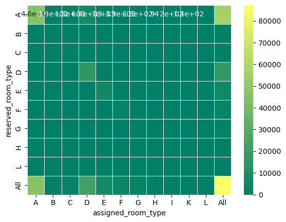

```python
sns.heatmap(pivot,annot=True,linewidth=0.5, cmap='summer')
```

#### Meaningful insight from this :

- For A category room , 56436 folks have reserved "A" & 45850 folks get assigned_room as "A".. & rest are unable to get !
- For B category room , 996 folks have reserved "B" & 872 folks get assigned_room as "B".. & rest are unable to get !

```python
# we will say just normalize over row , hence we need to pass normalize = 'index'

pivot_normalize = pd.crosstab(index = hotel_data['reserved_room_type'] , columns=hotel_data['assigned_room_type'] , margins=True ,normalize='index' ).round(2)*100
```

```python
pivot_normalize
```

| assigned_room_type reserved_room_type | A | B | C | D | E | F | G | H | I | K | L |
| --- | --- | --- | --- | --- | --- | --- | --- | --- | --- | --- | --- |
| A | 81.0 | 2.0 | 2.0 | 11.0 | 2.0 | 1.0 | 0.0 | 0.0 | 0.0 | 0.0 | 0.0 |
| B | 11.0 | 88.0 | 0.0 | 1.0 | 0.0 | 0.0 | 1.0 | 0.0 | 0.0 | 0.0 | 0.0 |
| C | 1.0 | 0.0 | 95.0 | 1.0 | 0.0 | 0.0 | 1.0 | 1.0 | 1.0 | 0.0 | 0.0 |
| D | 2.0 | 0.0 | 0.0 | 92.0 | 4.0 | 1.0 | 0.0 | 0.0 | 0.0 | 0.0 | 0.0 |
| E | 0.0 | 0.0 | 0.0 | 0.0 | 90.0 | 6.0 | 2.0 | 0.0 | 1.0 | 0.0 | 0.0 |
| F | 0.0 | 0.0 | 0.0 | 0.0 | 1.0 | 93.0 | 4.0 | 0.0 | 0.0 | 0.0 | 0.0 |
| G | 0.0 | 0.0 | 0.0 | 0.0 | 0.0 | 1.0 | 98.0 | 0.0 | 1.0 | 0.0 | 0.0 |
| H | 0.0 | 0.0 | 0.0 | 0.0 | 0.0 | 0.0 | 2.0 | 97.0 | 1.0 | 0.0 | 0.0 |
| L | 17.0 | 17.0 | 17.0 | 0.0 | 0.0 | 17.0 | 0.0 | 17.0 | 0.0 | 0.0 | 17.0 |
| All | 53.0 | 2.0 | 2.0 | 26.0 | 8.0 | 4.0 | 3.0 | 1.0 | 0.0 | 0.0 | 0.0 |

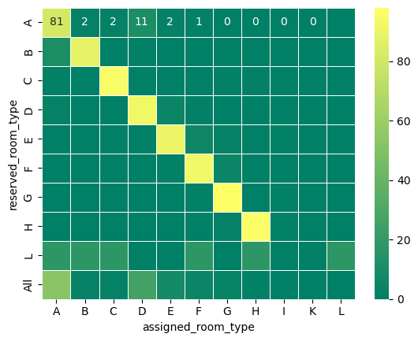

```python
sns.heatmap(pivot_normalize,annot=True,linewidth=0.5, cmap='summer')
```

Is any difference between assigned and reserved room type ? Yes

### 6. Bookings by market segment

```python
hotel_data['market_segment'].value_counts()
```

```
market_segment
Online TA        51553
Offline TA/TO    13855
Direct           11780
Groups            4922
Corporate         4200
Complementary      692
Aviation           226
Undefined            2
Name: count, dtype: int64
```

```python
hotel_data['market_segment'].value_counts().values
```

```
array([51553, 13855, 11780,  4922,  4200,   692,   226,     2],
      dtype=int64)
```

```python
hotel_data['market_segment'].value_counts().index
```

```
Index(['Online TA', 'Offline TA/TO', 'Direct', 'Groups', 'Corporate',
       'Complementary', 'Aviation', 'Undefined'],
      dtype='object', name='market_segment')
```

```python
# pie plot

fig = px.pie(hotel_data ,
      values = hotel_data['market_segment'].value_counts().values ,
      names = hotel_data['market_segment'].value_counts().index)
fig.show()
```

[interactive chart not shown]

#### Most of the bookings have been done in Online mode

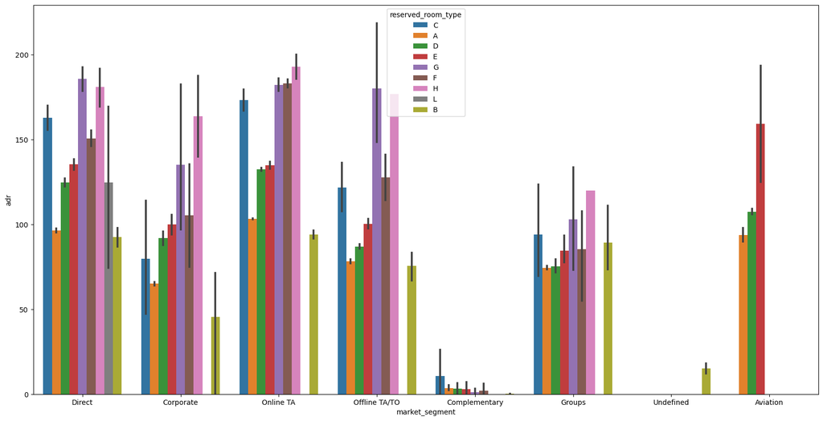

```python
# this plot tells avg adr of various room-types for all the market segment.
plt.figure(figsize=(20,10))
sns.barplot(x="market_segment" , y="adr" , hue="reserved_room_type" , data=hotel_data)
```

#### 7.Total guests arrival on each day:

Is there any pattern in guests arrival , ie whether Guests number have increased or not ?

```python
hotel_data['arrival_date_month'].unique()
```

```
array(['July', 'August', 'September', 'October', 'November', 'December',
       'January', 'February', 'March', 'April', 'May', 'June'],
      dtype=object)
```

```python
dict_month = {'July':7, 'August':8, 'September':9, 'October':10, 'November':11, 'December':12,
       'January':1, 'February':2, 'March':3, 'April':4, 'May':5, 'June':6}
```

```python
hotel_data['arrival_date_month_index'] = hotel_data['arrival_date_month'].map(dict_month)
```

```python
hotel_data['arrival_date_month'].unique()
```

```
array(['July', 'August', 'September', 'October', 'November', 'December',
       'January', 'February', 'March', 'April', 'May', 'June'],
      dtype=object)
```

```python
hotel_data['arrival_date_month_index']
```

```
0         7
1         7
2         7
3         7
4         7
         ..
119385    8
119386    8
119387    8
119388    8
119389    8
Name: arrival_date_month_index, Length: 87230, dtype: int64
```

```python
hotel_data.columns
```

```
Index(['hotel', 'is_canceled', 'lead_time', 'arrival_date_year',
       'arrival_date_month', 'arrival_date_week_number',
       'arrival_date_day_of_month', 'stays_in_weekend_nights',
       'stays_in_week_nights', 'adults', 'children', 'babies', 'meal',
       'country', 'market_segment', 'distribution_channel',
       'is_repeated_guest', 'previous_cancellations',
       'previous_bookings_not_canceled', 'reserved_room_type',
       'assigned_room_type', 'booking_changes', 'deposit_type', 'agent',
       'company', 'days_in_waiting_list', 'customer_type', 'adr',
       'required_car_parking_spaces', 'total_of_special_requests',
       'reservation_status', 'reservation_status_date',
       'arrival_date_month_index'],
      dtype='object')
```

```python
hotel_data[['arrival_date_year','arrival_date_month_index','arrival_date_day_of_month']]
```

|  | arrival_date_year | arrival_date_month_index | arrival_date_day_of_month |
| --- | --- | --- | --- |
| 0 | 2015 | 7 | 1 |
| 1 | 2015 | 7 | 1 |
| 2 | 2015 | 7 | 1 |
| 3 | 2015 | 7 | 1 |
| 4 | 2015 | 7 | 1 |
| ... | ... | ... | ... |
| 119385 | 2017 | 8 | 30 |
| 119386 | 2017 | 8 | 31 |
| 119387 | 2017 | 8 | 31 |
| 119388 | 2017 | 8 | 31 |
| 119389 | 2017 | 8 | 29 |

87230 rows × 3 columns

```python
## we need to use .astype(str) to convert int values to string,otherwise we are unable to perform this string concatenation operation
hotel_data['arrival_date'] = hotel_data['arrival_date_year'].astype(str) + '-' + hotel_data['arrival_date_month_index'].astype(str) + '-' + hotel_data['arrival_date_day_of_month'].astype(str)
```

```python
hotel_data['arrival_date']
```

```
0          2015-7-1
1          2015-7-1
2          2015-7-1
3          2015-7-1
4          2015-7-1
            ...
119385    2017-8-30
119386    2017-8-31
119387    2017-8-31
119388    2017-8-31
119389    2017-8-29
Name: arrival_date, Length: 87230, dtype: object
```

#### Guests

```python
hotel_data[['adults', 'children', 'babies']]
```

|  | adults | children | babies |
| --- | --- | --- | --- |
| 0 | 2 | 0.0 | 0 |
| 1 | 2 | 0.0 | 0 |
| 2 | 1 | 0.0 | 0 |
| 3 | 1 | 0.0 | 0 |
| 4 | 2 | 0.0 | 0 |
| ... | ... | ... | ... |
| 119385 | 2 | 0.0 | 0 |
| 119386 | 3 | 0.0 | 0 |
| 119387 | 2 | 0.0 | 0 |
| 119388 | 2 | 0.0 | 0 |
| 119389 | 2 | 0.0 | 0 |

87230 rows × 3 columns

```python
hotel_data['Total_guests'] = hotel_data['adults'] + hotel_data['children'] + hotel_data['babies']
```

```python
hotel_data['Total_guests']
```

```
0         2.0
1         2.0
2         1.0
3         1.0
4         2.0
         ...
119385    2.0
119386    3.0
119387    2.0
119388    2.0
119389    2.0
Name: Total_guests, Length: 87230, dtype: float64
```

```python
hotel_data.columns
```

```
Index(['hotel', 'is_canceled', 'lead_time', 'arrival_date_year',
       'arrival_date_month', 'arrival_date_week_number',
       'arrival_date_day_of_month', 'stays_in_weekend_nights',
       'stays_in_week_nights', 'adults', 'children', 'babies', 'meal',
       'country', 'market_segment', 'distribution_channel',
       'is_repeated_guest', 'previous_cancellations',
       'previous_bookings_not_canceled', 'reserved_room_type',
       'assigned_room_type', 'booking_changes', 'deposit_type', 'agent',
       'company', 'days_in_waiting_list', 'customer_type', 'adr',
       'required_car_parking_spaces', 'total_of_special_requests',
       'reservation_status', 'reservation_status_date',
       'arrival_date_month_index', 'arrival_date', 'Total_guests'],
      dtype='object')
```

```python
hotel_data.shape
```

```
(87230, 35)
```

```python
hotel_data[['arrival_date', 'Total_guests']]
```

|  | arrival_date | Total_guests |
| --- | --- | --- |
| 0 | 2015-7-1 | 2.0 |
| 1 | 2015-7-1 | 2.0 |
| 2 | 2015-7-1 | 1.0 |
| 3 | 2015-7-1 | 1.0 |
| 4 | 2015-7-1 | 2.0 |
| ... | ... | ... |
| 119385 | 2017-8-30 | 2.0 |
| 119386 | 2017-8-31 | 3.0 |
| 119387 | 2017-8-31 | 2.0 |
| 119388 | 2017-8-31 | 2.0 |
| 119389 | 2017-8-29 | 2.0 |

87230 rows × 2 columns

```python
dataNoCancel = hotel_data[hotel_data['is_canceled']==0]
```

```python
dataNoCancel
```

|  | hotel | is_canceled | lead_time | arrival_date_year | arrival_date_month | arrival_date_week_number | arrival_date_day_of_month | stays_in_weekend_nights | stays_in_week_nights | adults | ... | days_in_waiting_list | customer_type | adr | required_car_parking_spaces | total_of_special_requests | reservation_status | reservation_status_date | arrival_date_month_index | arrival_date | Total_guests |
| --- | --- | --- | --- | --- | --- | --- | --- | --- | --- | --- | --- | --- | --- | --- | --- | --- | --- | --- | --- | --- | --- |
| 0 | Resort Hotel | 0 | 342 | 2015 | July | 27 | 1 | 0 | 0 | 2 | ... | 0 | Transient | 0.00 | 0 | 0 | Check-Out | 7/1/2015 | 7 | 2015-7-1 | 2.0 |
| 1 | Resort Hotel | 0 | 737 | 2015 | July | 27 | 1 | 0 | 0 | 2 | ... | 0 | Transient | 0.00 | 0 | 0 | Check-Out | 7/1/2015 | 7 | 2015-7-1 | 2.0 |
| 2 | Resort Hotel | 0 | 7 | 2015 | July | 27 | 1 | 0 | 1 | 1 | ... | 0 | Transient | 75.00 | 0 | 0 | Check-Out | 7/2/2015 | 7 | 2015-7-1 | 1.0 |
| 3 | Resort Hotel | 0 | 13 | 2015 | July | 27 | 1 | 0 | 1 | 1 | ... | 0 | Transient | 75.00 | 0 | 0 | Check-Out | 7/2/2015 | 7 | 2015-7-1 | 1.0 |
| 4 | Resort Hotel | 0 | 14 | 2015 | July | 27 | 1 | 0 | 2 | 2 | ... | 0 | Transient | 98.00 | 0 | 1 | Check-Out | 7/3/2015 | 7 | 2015-7-1 | 2.0 |
| ... | ... | ... | ... | ... | ... | ... | ... | ... | ... | ... | ... | ... | ... | ... | ... | ... | ... | ... | ... | ... | ... |
| 119385 | City Hotel | 0 | 23 | 2017 | August | 35 | 30 | 2 | 5 | 2 | ... | 0 | Transient | 96.14 | 0 | 0 | Check-Out | 9/6/2017 | 8 | 2017-8-30 | 2.0 |
| 119386 | City Hotel | 0 | 102 | 2017 | August | 35 | 31 | 2 | 5 | 3 | ... | 0 | Transient | 225.43 | 0 | 2 | Check-Out | 9/7/2017 | 8 | 2017-8-31 | 3.0 |
| 119387 | City Hotel | 0 | 34 | 2017 | August | 35 | 31 | 2 | 5 | 2 | ... | 0 | Transient | 157.71 | 0 | 4 | Check-Out | 9/7/2017 | 8 | 2017-8-31 | 2.0 |
| 119388 | City Hotel | 0 | 109 | 2017 | August | 35 | 31 | 2 | 5 | 2 | ... | 0 | Transient | 104.40 | 0 | 0 | Check-Out | 9/7/2017 | 8 | 2017-8-31 | 2.0 |
| 119389 | City Hotel | 0 | 205 | 2017 | August | 35 | 29 | 2 | 7 | 2 | ... | 0 | Transient | 151.20 | 0 | 2 | Check-Out | 9/7/2017 | 8 | 2017-8-29 | 2.0 |

63221 rows × 35 columns

```python
guest_arrival_series = dataNoCancel.groupby(['arrival_date'])['Total_guests'].sum()
```

```python
guest_arrival_series
```

```
arrival_date
2015-10-1     149.0
2015-10-10    167.0
2015-10-11    123.0
2015-10-12    186.0
2015-10-13    115.0
              ...
2017-8-5      205.0
2017-8-6      199.0
2017-8-7      287.0
2017-8-8      191.0
2017-8-9      185.0
Name: Total_guests, Length: 793, dtype: float64
```

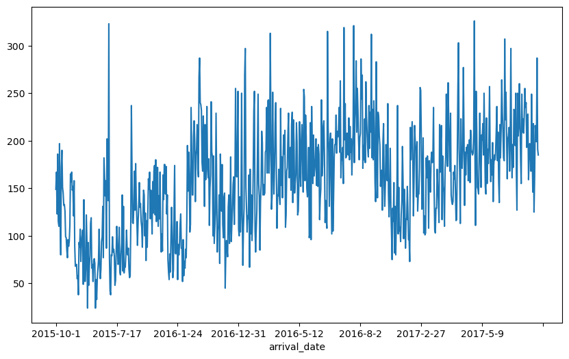

```python
guest_arrival_series.plot(figsize=(10,6))
```

Is there any pattern ? No , there is no visible pattern in guests arrival in this line-plot as we have some un-even trend .

#### 8.Analysing distribution of "guests arrival"

```python
guest_arrival_series
```

```
arrival_date
2015-10-1     149.0
2015-10-10    167.0
2015-10-11    123.0
2015-10-12    186.0
2015-10-13    115.0
              ...
2017-8-5      205.0
2017-8-6      199.0
2017-8-7      287.0
2017-8-8      191.0
2017-8-9      185.0
Name: Total_guests, Length: 793, dtype: float64
```

```python
guest_arrival_series.values

## lets obtain array representation of Series so that it is easy to get our distribution ..
```

```
array([149., 167., 123., 186., 115., 110., 197., 118.,  80., 172., 190.,
       151., 145., 132., 133., 126.,  99.,  98.,  85.,  77.,  96.,  89.,
        94., 111., 165., 157., 167., 148., 152., 121., 158.,  89.,  68.,
        69.,  70.,  55.,  58.,  38.,  93.,  88., 107.,  73.,  92., 100.,
       106.,  49., 138.,  81.,  52.,  64., 122.,  95.,  24.,  93.,  48.,
        68.,  79., 113., 119.,  66.,  70.,  52.,  74.,  76.,  71.,  24.,
        54.,  33.,  55.,  64.,  74., 107.,  68.,  55.,  65.,  94.,  99.,
       131.,  77., 182., 161., 142., 158.,  87., 202., 174., 137., 323.,
        77.,  42.,  38.,  80.,  79.,  99.,  83.,  86.,  79.,  48.,  53.,
        80., 110.,  93.,  70.,  71., 109.,  62.,  59.,  80.,  92., 143.,
        63., 131.,  61.,  70.,  67.,  81., 106.,  87.,  80.,  87.,  65.,
        56.,  58., 111., 237., 171., 114., 113., 131., 168., 127., 176.,
       137., 116.,  90., 114., 132., 156., 130., 134., 115., 109.,  88.,
       122., 148., 143., 100., 124.,  74., 116.,  88., 125., 160., 149.,
       167., 118., 148., 135., 102., 157., 124., 168., 174., 122., 180.,
       115., 132., 172., 110., 142., 118., 167., 112.,  83., 102.,  84.,
       164., 138., 175., 175., 144., 173., 123., 143.,  75.,  62.,  54.,
        81.,  62.,  99., 130., 101.,  56.,  64., 126., 174.,  82.,  81.,
        87., 115.,  54.,  91.,  80.,  90., 112., 123.,  87.,  87.,  52.,
        96.,  58.,  73.,  66.,  86.,  77., 116., 195., 147., 188., 165.,
       104., 112., 235., 189., 143., 143., 204., 221., 199., 136., 185.,
       191., 217., 170., 162., 267., 287., 240., 238., 232., 177., 168.,
       226., 197., 131., 217., 159., 178., 236., 170., 161., 181., 111.,
       150., 164., 241., 188., 183., 100., 184.,  92., 109., 124., 229.,
       156.,  83., 109., 108., 143.,  71., 186., 159., 126., 175., 112.,
        98., 141., 145.,  45.,  80.,  95.,  86.,  78., 130., 143.,  92.,
       117., 183.,  94., 113., 128., 154., 162., 112., 152., 255., 164.,
       162., 197., 252., 107., 100., 141., 104., 131., 250., 122.,  69.,
       109., 129., 269., 297., 152., 130., 104., 121., 118., 164.,  67.,
       170., 102., 143.,  95., 118., 167., 231., 252., 106.,  83., 107.,
       127., 190., 249., 155., 141.,  85., 136., 155., 210., 198., 143.,
       154., 143., 145., 188., 190., 235., 166., 242., 243., 166., 190.,
       313., 215., 128., 142., 251., 179., 144., 174., 219., 240., 169.,
       108., 143., 142., 170., 142., 133., 234., 153., 183., 140., 177.,
       206., 186., 211., 109., 122., 168., 172., 206., 229., 161., 174.,
       193., 148., 217., 230., 135., 222., 198., 145., 156., 164., 219.,
       198., 122., 126., 155., 220., 170., 152., 201., 217., 179., 146.,
       254., 246., 158., 227., 204., 150., 141., 150., 193.,  98., 104.,
       219.,  96., 236., 192., 155., 206., 163., 170., 180., 202., 153.,
       193., 152., 196., 186., 117., 139., 149., 243., 163., 174., 215.,
```

[output cut: 18 more lines]

```
       110., 170., 183., 249., 201., 173., 261., 221., 190., 168., 229.,
       143., 136., 133., 136., 167., 160., 174., 147., 116., 117., 181.,
       253., 303., 192., 167., 113., 223., 176., 171., 191., 277., 212.,
       132., 188., 164., 193., 187., 196., 158., 170., 201., 156., 211.,
       191., 188., 185., 187., 208., 326., 191., 111., 252., 212., 151.,
       149., 144., 187., 229., 183., 151., 206., 201., 218., 185., 250.,
       198., 152., 144., 224., 155., 191., 176., 203., 257., 184., 157.,
       180., 164., 198., 136., 175., 185., 180., 189., 210., 236., 179.,
       209., 157., 135., 217., 182., 211., 264., 230., 211., 182., 179.,
       307., 222., 251., 208., 160., 202., 205., 214., 168., 206., 297.,
       189., 161., 196., 172., 233., 231., 195., 250., 167., 127., 250.,
       205., 215., 260., 222., 181., 155., 249., 209., 223., 208., 227.,
       255., 235., 240., 193., 225., 228., 159., 180., 197., 189., 168.,
       249., 189., 146., 218., 125., 160., 216., 205., 199., 287., 191.,
       185.])
```

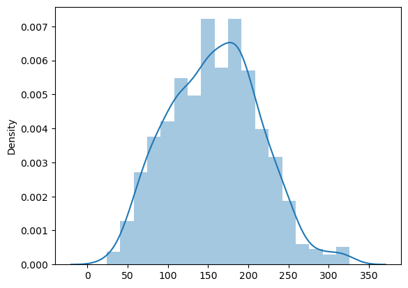

```python
sns.distplot(guest_arrival_series.values )
```

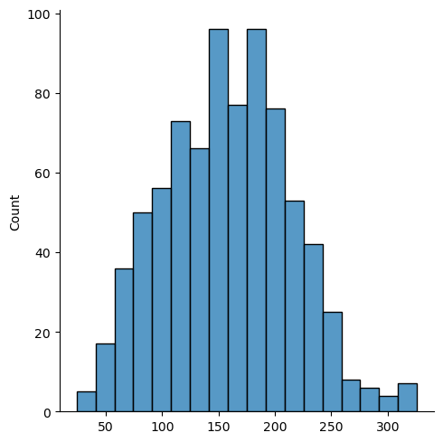

```python
sns.displot(guest_arrival_series.values )
```

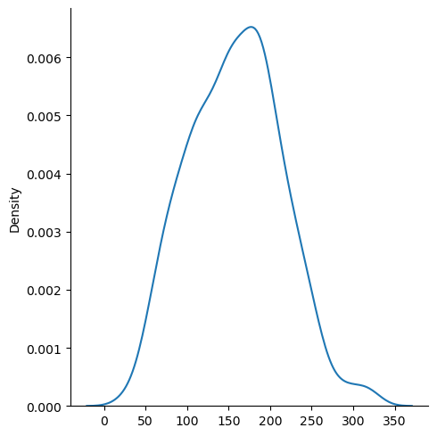

```python
sns.displot(guest_arrival_series.values , kind='kde' )
```

```python
np.mean(guest_arrival_series.values)
```

```
157.92559899117276
```

```python
np.median(guest_arrival_series.values)
```

```
158.0
```

```python
np.std(guest_arrival_series.values)
```

```
56.48263702610786
```

The histogram with a KDE plot shows the distribution of guest arrivals, suggesting a dataset that includes arrival_date and Total_guests.

- Distribution Shape: The data appears to follow a roughly normal distribution, with a single peak and symmetric tails. This suggests that most guest arrival numbers are centered around a mean value, with fewer occurrences of extremely high or low guest numbers.
- Skewness: The distribution does not appear to be significantly skewed, suggesting a balance in the frequency of guest arrivals on either side of the mean.
- Kurtosis: The height and sharpness of the peak, along with the tails of the distribution, suggest moderate kurtosis. This indicates that the data has a pronounced peak but is not excessively peaked or flat.